# Ch6 Analysis of longitudinal data

*Describe the work you have done this week and summarize your learning.*

- Describe your work and results clearly.
- Assume the reader has an introductory course level understanding of writing and reading R code as well as statistical methods.
- Assume the reader has no previous knowledge of your data or the more advanced methods you are using.

```r
date()
```

```
## [1] "Mon Dec 12 22:35:24 2022"
```

**Here we go again!**

[figure not shown]

*Sweet, sweet longitudinal data…*

For **longitudinal data we cannot assume observations to be independent of each other**, since longitudinal data means multiple observations of the *same* individuals. For this assignment we’ll first do some data wrangling to transform our data form wide form to long for. Then we’ll analyse our data with linear mixed effects statistical models; a random intercept model and a random intercept and slope model.

## Libraries used for Ch6

Obs! You might need to install some packages first if you haven’t used them before (see install.packages()).

```r
#install.packages(c("tidyverse","GGally","readr", "MASS", "corrplot", "psych"))
```

Load the needed R packages before getting to work:

```r
#load required packages
library(tidyverse)
#library(GGally)
#library(dplyr)
library(ggplot2)
#library(corrplot)
#library(stringr)
#library(psych)
#library(FactoMineR)
library(lme4)
```

## Data wrangling (5p.)

See meet_and_repeat.R on [my repository](https://github.com/hsanez/IODS-project/tree/master/data/meet_and_repeat.R) for the data wrangling part.

## Data Analysis (15p.)

### 1. Analysis from ch 8 of MABS - Analysis of Longitudinal Data I: Graphical Displays and Summary Measure Approach

For the first part of the analysis, graphical displays and summary measure approach to longitudinal data we’ll use the wrangled ‘rats’ dataset now found in [my repository](https://github.com/hsanez/IODS-project/tree/master/data).

```r
# read long format data of rats
ratsL <- read.csv('rats_long.csv', row.names = 1)

# glimpse and dimensions
head(ratsL);dim(ratsL)
```

```
##   ID Group  WD Weight Time
## 1  1     1 WD1    240    1
## 2  2     1 WD1    225    1
## 3  3     1 WD1    245    1
## 4  4     1 WD1    260    1
## 5  5     1 WD1    255    1
## 6  6     1 WD1    260    1
```

```
## [1] 176   5
```

```r
# structure and summary of the data
str(ratsL)
```

```
## 'data.frame':    176 obs. of  5 variables:
##  $ ID    : int  1 2 3 4 5 6 7 8 9 10 ...
##  $ Group : int  1 1 1 1 1 1 1 1 2 2 ...
##  $ WD    : chr  "WD1" "WD1" "WD1" "WD1" ...
##  $ Weight: int  240 225 245 260 255 260 275 245 410 405 ...
##  $ Time  : int  1 1 1 1 1 1 1 1 1 1 ...
```

```r
summary(ratsL)
```

```
##        ID            Group           WD                Weight
##  Min.   : 1.00   Min.   :1.00   Length:176         Min.   :225.0
##  1st Qu.: 4.75   1st Qu.:1.00   Class :character   1st Qu.:267.0
##  Median : 8.50   Median :1.50   Mode  :character   Median :344.5
##  Mean   : 8.50   Mean   :1.75                      Mean   :384.5
##  3rd Qu.:12.25   3rd Qu.:2.25                      3rd Qu.:511.2
##  Max.   :16.00   Max.   :3.00                      Max.   :628.0
##       Time
##  Min.   : 1.00
##  1st Qu.:15.00
##  Median :36.00
##  Mean   :33.55
##  3rd Qu.:50.00
##  Max.   :64.00
```

```r
# Convert categorical data to factors
## ID and Group
ratsL$ID <- factor(ratsL$ID)
ratsL$Group <- factor(ratsL$Group)
```

Let’s plot the Weights of each rat by time and groups.

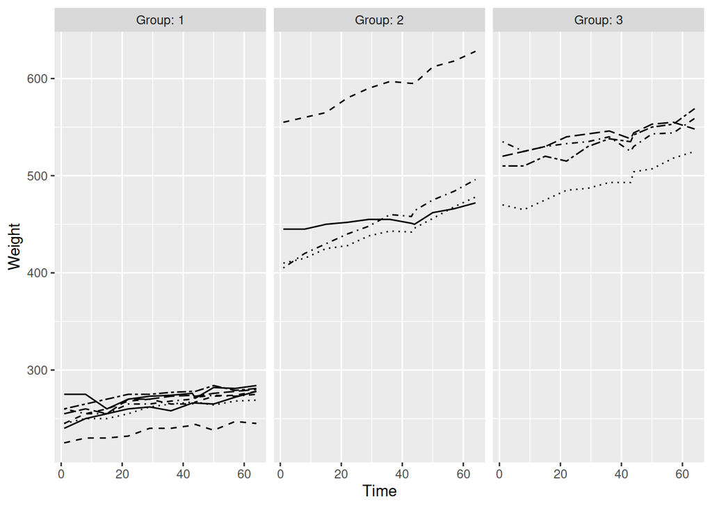

```r
# Draw the plot
ggplot(ratsL, aes(x = Time, y = Weight, linetype = ID)) +
  geom_line() +
  scale_linetype_manual(values = rep(1:10, times=4)) +
  facet_grid(. ~ Group, labeller = label_both) +
  theme(legend.position = "none") +
  scale_y_continuous(limits = c(min(ratsL$Weight), max(ratsL$Weight)))
```

The weight of each rat increases though the days. Group 1 has the most rats, group 2 and 3 include both 4 rats. Both the baseline and final weights of the rats increase by group, group 1 having rats with the lowest weights and group 3 the highest. One rat in group 2 has the highest baseline and final weight.

**Standardizing to assess the tracking phenomenon**

Higher baseline weight may mean higher final weight. This is called the tracking phenomenon. The plots drawn earlier sufggest this might be the case in our data. We’ll can assess this more clearly with plotting standardized data.

We’ll standardize our data with scale():

$$standardised(x) = \frac{x - mean(x)}{
sd(x)}$$

```r
# Standardise the variable Weight by groups´
ratsL <- ratsL %>%
  group_by(Time) %>%
  mutate(Weight_std= (scale(Weight))) %>%
  ungroup()

# Glimpse the data
head(ratsL)
```

```
## # A tibble: 6 × 6
##   ID    Group WD    Weight  Time Weight_std[,1]
##   <fct> <fct> <chr>  <int> <int>          <dbl>
## 1 1     1     WD1      240     1         -1.00
## 2 2     1     WD1      225     1         -1.12
## 3 3     1     WD1      245     1         -0.961
## 4 4     1     WD1      260     1         -0.842
## 5 5     1     WD1      255     1         -0.882
## 6 6     1     WD1      260     1         -0.842
```

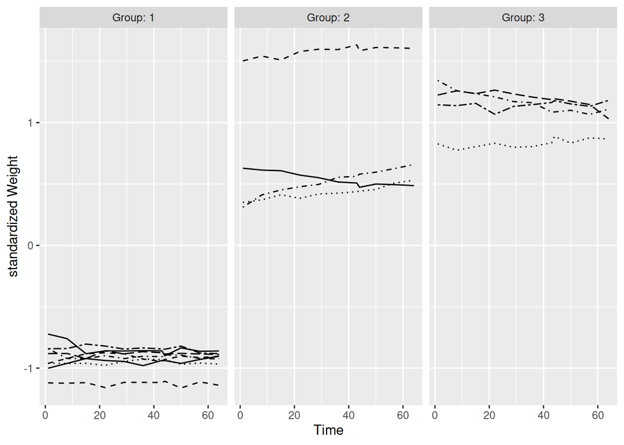

```r
# Plot again with the standardised weight
ggplot(ratsL, aes(x = Time, y = Weight_std, linetype = ID)) +
  geom_line() +
  scale_linetype_manual(values = rep(1:10, times=4)) +
  facet_grid(. ~ Group, labeller = label_both) +
  theme(legend.position = "none") +
  scale_y_continuous(name = "standardized Weight")
```

After standardizing our data the difference between the baseline and final weights looks smaller in the plot.

**Summary graphs**

As our course material indicates, we can produce graphs showing average (mean) profiles for each group along with some indication of the variation of the observations at each time point (*the standard error of mean*):

$$se = \frac{sd(x)}{\sqrt{n}}$$

```r
# Summary data with mean and standard error of bprs by treatment and week
ratsLs <- ratsL %>%
  group_by(Group, Time) %>%
  summarise(mean = mean(Weight), se = (sd(Weight)/sqrt(length(Weight))) ) %>%
  ungroup()

# Glimpse the data
glimpse(ratsLs)
```

```
## Rows: 33
## Columns: 4
## $ Group <fct> 1, 1, 1, 1, 1, 1, 1, 1, 1, 1, 1, 2, 2, 2, 2, 2, 2, 2, 2, 2, 2, 2…
## $ Time  <int> 1, 8, 15, 22, 29, 36, 43, 44, 50, 57, 64, 1, 8, 15, 22, 29, 36, …
## $ mean  <dbl> 250.625, 255.000, 254.375, 261.875, 264.625, 265.000, 267.375, 2…
## $ se    <dbl> 5.381640, 4.629100, 4.057346, 4.808614, 3.909409, 4.166190, 3.87…
```

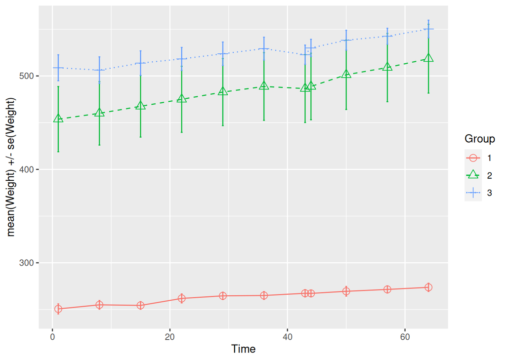

```r
# Plot the mean profiles
ggplot(ratsLs, aes(x = Time, y = mean, color=Group, linetype = Group, shape = Group)) +
  geom_line() +
  scale_linetype_manual(values = c(1,2,3)) +
  geom_point(size=3) +
  scale_shape_manual(values = c(1,2,3)) +
  geom_errorbar(aes(ymin=mean-se, ymax=mean+se, linetype="1"), width=0.3) +
  # legend inside plot
  #theme(legend.position = c(0.8,0.4)) +
  scale_y_continuous(name = "mean(Weight) +/- se(Weight)")
```

**Summary measure approach**

Let’s look at the weight measurements after the start of the study (= we’ll exclude baseline - i.e. week 1- weights). We’ll calculate the mean weight for each rat, and then draw boxplots of the mean weight for each diet group.

```r
# Create a summary data by group and subject with mean as the summary variable (ignoring baseline week 1)
ratsL_sum <- ratsL %>%
  filter(Time > 1) %>%
  group_by(Group, ID) %>%
  summarise(Weight_mean=mean(Weight)) %>%
  ungroup()

# Glimpse the data
glimpse(ratsL_sum)
```

```
## Rows: 16
## Columns: 3
## $ Group       <fct> 1, 1, 1, 1, 1, 1, 1, 1, 2, 2, 2, 2, 3, 3, 3, 3
## $ ID          <fct> 1, 2, 3, 4, 5, 6, 7, 8, 9, 10, 11, 12, 13, 14, 15, 16
## $ Weight_mean <dbl> 263.2, 238.9, 261.7, 267.2, 270.9, 276.2, 274.6, 267.5, 44…
```

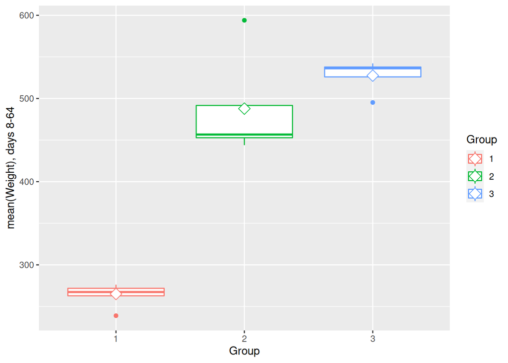

```r
# Draw a boxplot of the mean versus diet
ggplot(ratsL_sum, aes(x = Group, y = Weight_mean, col=Group)) +
  geom_boxplot() +
  stat_summary(fun = "mean", geom = "point", shape=23, size=4, fill = "white") +
  scale_y_continuous(name = "mean(Weight), days 8-64")
```

The mean summary measure is more variable in the second treatment group and its distribution in this group is somewhat skew. All of the three groups seem to have an outlier - the mean weight of the rat is more than 1.5 times the interquartile range above the upper quartile or below the lower quartile. These outliers might bias the conclusions from the later comparisons of the groups so we’ll remove them from out analysis and redraw the boxplots. Outlier in group 3 is within the filtering limits (min and max of the means of all groups) so we’ll have to search the rat ID for that outlier to exclude it from the group.

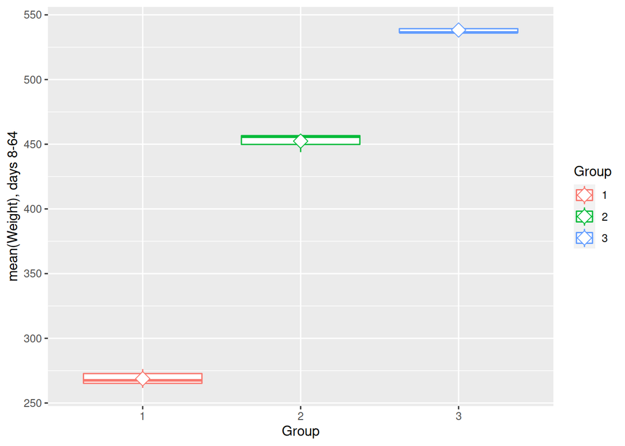

```r
# define outlier from group 3
g3 <- ratsL_sum %>% filter(Group==3)
out3 <- min(g3$Weight_mean)

# Create a new data by filtering the outliers
ratsL_sum2 <- ratsL_sum %>%
  filter(250 < Weight_mean & Weight_mean < 560 & Weight_mean != out3)


# Draw a boxplot of the mean versus diet
ggplot(ratsL_sum2, aes(x = Group, y = Weight_mean, col=Group)) +
  geom_boxplot() +
  stat_summary(fun = "mean", geom = "point", shape=23, size=4, fill = "white") +
  scale_y_continuous(name = "mean(Weight), days 8-64")
```

There is less within group variation after excluding the outliers and we may proceed with our analysis.

*T-test or analysis of variance (ANOVA) or analysis of covariance (ANCOVA)*

Based on our previous plots, there seems to be a difference in weights in our diet groups. We’ll now test if there is a statistical difference and whether it is statistically significant.

T-test tests whether there is a statistical difference between two groups and ANOVA test whether there is a difference between three or more groups. Thus, we’ll use ANOVA for our analysis.

ANOVA assumes homogeneity of variance - the variance in groups 1-3 should be similar. We’ll test this with Levene’s test before proceeding further with ANOVA.

```r
# Levene's test from 'car' package
library(car)
leveneTest(Weight_mean ~ Group, ratsL_sum2)
```

```
## Levene's Test for Homogeneity of Variance (center = median)
##       Df F value Pr(>F)
## group  2  0.3727  0.698
##       10
```

The Levene’s test returned a nonsignificant p value for the difference of variances between groups: we’ll accept the test’s null hypothesis -> there is no difference between the variance of the groups 1-3. > We may proceed with ANOVA.

```r
# Fit the linear model with the mean Weight as the response
fit <- lm(Weight_mean ~ Group, data = ratsL_sum2)

# Compute the analysis of variance table for the fitted model with anova()
anova(fit)
```

```
## Analysis of Variance Table
##
## Response: Weight_mean
##           Df Sum Sq Mean Sq F value    Pr(>F)
## Group      2 176917   88458  2836.4 1.687e-14 ***
## Residuals 10    312      31
## ---
## Signif. codes:  0 '***' 0.001 '**' 0.01 '*' 0.05 '.' 0.1 ' ' 1
```

This shows there seems to be a significant difference in mean weights between diet groups.

However, we should take into account baseline weight to assess the differences in mean weights of groups 1-3 while accounting for the tracking phenomenon. We’ll add the baseline weight from the original dataset rats and run ANCOVA.

```r
# Load original wide form rats data
rats_og <- as_tibble(read.table("https://raw.githubusercontent.com/KimmoVehkalahti/MABS/master/Examples/data/rats.txt", header = TRUE, sep = '\t'))
rats_og$ID <- factor(rats_og$ID)
#rats_og$Group <- factor(rats_og$Group)

# Add the baseline from the original data as a new variable to the summary data
join_vars <- c("ID","WD1")
ratsL_sum3 <- ratsL_sum2 %>%
  left_join(rats_og[join_vars], by='ID')
# Rename column
ratsL_sum3 <- ratsL_sum3 %>%
  rename('Weight_baseline' = 'WD1')

# Fit the linear model with the mean Weight as the response
fit2 <- lm(Weight_mean ~ Weight_baseline + Group, data = ratsL_sum3)

# Compute the analysis of variance table for the fitted model with anova()
anova(fit2)
```

```
## Analysis of Variance Table
##
## Response: Weight_mean
##                 Df Sum Sq Mean Sq  F value    Pr(>F)
## Weight_baseline  1 174926  174926 6630.941 3.216e-14 ***
## Group            2   2065    1033   39.147 3.628e-05 ***
## Residuals        9    237      26
## ---
## Signif. codes:  0 '***' 0.001 '**' 0.01 '*' 0.05 '.' 0.1 ' ' 1
```

Baseline weight is strongly correlated with mean weight later in the study. However, diet (Group) seems to keep it’s statistically significant association to weight even after taking baseline weight into account. The result is in line with our graphical overview of the dataset after exclusion of outliers.

### 2. Analysis from ch 9 of MABS - Analysis of Longitudinal Data II: Linear Mixed Effects Models for Normal Response Variables

In part II of this assignment we’ll use the dataset BPRS, which includes psychiatric patient data. It includes a brief psychiatric rating scale (BPRS) score prior to treatment and BPRS from 8 weeks during treatment. The patients (n=40) have been randomly assigned to treatment arm 1 or 2 and we are interested whether there is a difference in BPRS scores depending on the received treatment. A lower score means less symptoms.

We’ll first explore the data and then analyse it to determine whether the BPRS scores of the two treatment groups differ.

```r
# read in the data
BPRSL <- read.csv('BPRS_long.csv', row.names=1)
head(BPRSL);dim(BPRSL)
```

```
##   treatment subject weeks bprs week
## 1         1       1 week0   42    0
## 2         1       2 week0   58    0
## 3         1       3 week0   54    0
## 4         1       4 week0   55    0
## 5         1       5 week0   72    0
## 6         1       6 week0   48    0
```

```
## [1] 360   5
```

```r
View(BPRSL)

# Factor variables subject and treatment group
BPRSL$subject <- factor(BPRSL$subject)
BPRSL$treatment <- factor(BPRSL$treatment)

# Glimpse the data
glimpse(BPRSL)
```

```
## Rows: 360
## Columns: 5
## $ treatment <fct> 1, 1, 1, 1, 1, 1, 1, 1, 1, 1, 1, 1, 1, 1, 1, 1, 1, 1, 1, 1, …
## $ subject   <fct> 1, 2, 3, 4, 5, 6, 7, 8, 9, 10, 11, 12, 13, 14, 15, 16, 17, 1…
## $ weeks     <chr> "week0", "week0", "week0", "week0", "week0", "week0", "week0…
## $ bprs      <int> 42, 58, 54, 55, 72, 48, 71, 30, 41, 57, 30, 55, 36, 38, 66, …
## $ week      <int> 0, 0, 0, 0, 0, 0, 0, 0, 0, 0, 0, 0, 0, 0, 0, 0, 0, 0, 0, 0, …
```

From glimpsing and viewing the data we notice that in treatment arms the subjects are coded 1-20. However, these individuals with the same subject code are different individuals since all participating patients were randomized to either treatment 1 or treatment 2. To avoid mixups in our analysis we’ll have to create a new individual-specific factor ID-variable.

```r
# New ID-variable
BPRSL <- BPRSL %>%
  mutate(ID = as.factor(paste0(subject, "_t",treatment)))

# check data
glimpse(BPRSL)
```

```
## Rows: 360
## Columns: 6
## $ treatment <fct> 1, 1, 1, 1, 1, 1, 1, 1, 1, 1, 1, 1, 1, 1, 1, 1, 1, 1, 1, 1, …
## $ subject   <fct> 1, 2, 3, 4, 5, 6, 7, 8, 9, 10, 11, 12, 13, 14, 15, 16, 17, 1…
## $ weeks     <chr> "week0", "week0", "week0", "week0", "week0", "week0", "week0…
## $ bprs      <int> 42, 58, 54, 55, 72, 48, 71, 30, 41, 57, 30, 55, 36, 38, 66, …
## $ week      <int> 0, 0, 0, 0, 0, 0, 0, 0, 0, 0, 0, 0, 0, 0, 0, 0, 0, 0, 0, 0, …
## $ ID        <fct> 1_t1, 2_t1, 3_t1, 4_t1, 5_t1, 6_t1, 7_t1, 8_t1, 9_t1, 10_t1,…
```

```r
summary(BPRSL)
```

```
##  treatment    subject       weeks                bprs            week
##  1:180     1      : 18   Length:360         Min.   :18.00   Min.   :0
##  2:180     2      : 18   Class :character   1st Qu.:27.00   1st Qu.:2
##            3      : 18   Mode  :character   Median :35.00   Median :4
##            4      : 18                      Mean   :37.66   Mean   :4
##            5      : 18                      3rd Qu.:43.00   3rd Qu.:6
##            6      : 18                      Max.   :95.00   Max.   :8
##            (Other):252
##        ID
##  1_t1   :  9
##  1_t2   :  9
##  10_t1  :  9
##  10_t2  :  9
##  11_t1  :  9
##  11_t2  :  9
##  (Other):306
```

Let’s plot!

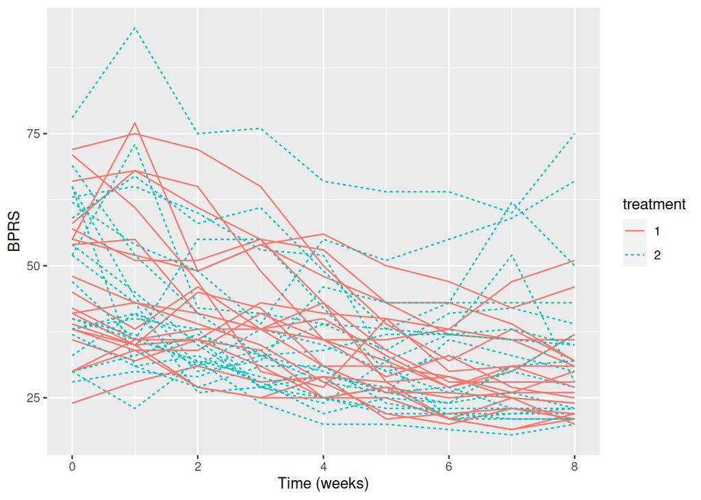

```r
# Plot the data
ggplot(BPRSL, aes(x = week, y = bprs, group = ID,  col=treatment)) +
  geom_line(aes(linetype=treatment)) +
  scale_x_continuous(name = "Time (weeks)", breaks = seq(0,8,2)) +
  scale_y_continuous(name="BPRS") +
  theme(legend.position = "right")
```

BPRS seems to decrease during the treatment period in both treatment arms. There is no clear difference to be seen between the groups. We’ll divide the plot into two separate plots by treatment.

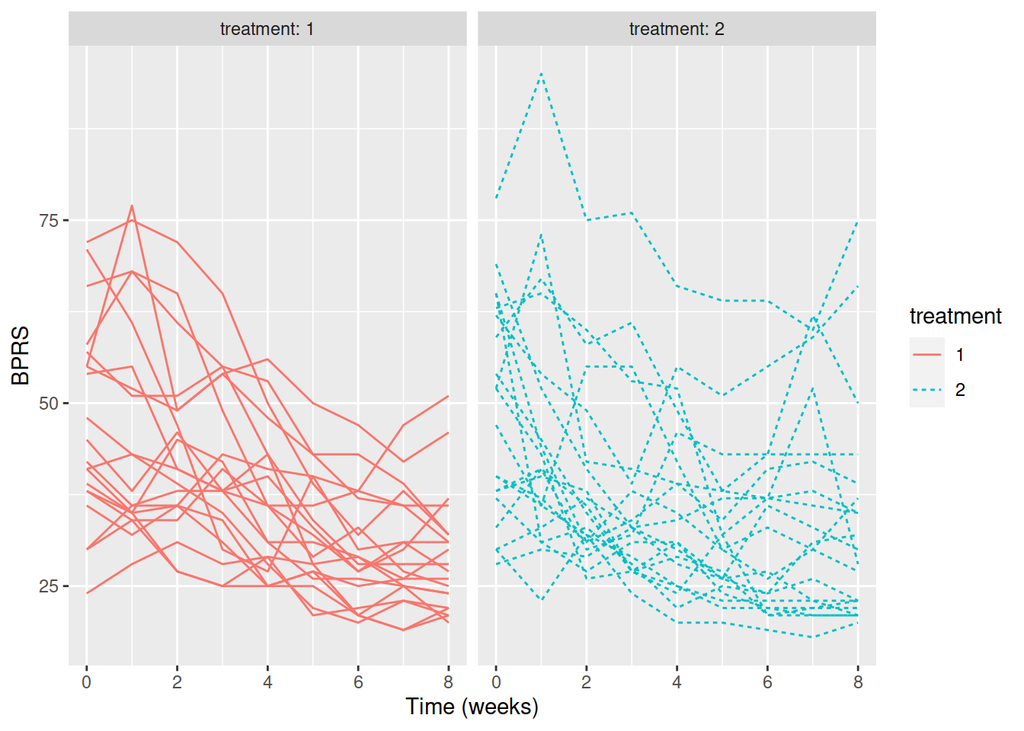

Still, we cannot draw trustworthy conclusions of these two treatment arms affecting BPRS. Let’s proceed.

**Linear Mixed Effects Models**

Now things are getting serious. **LET’S GO!**

[figure not shown]

*Linear model*

When fitting a linear model to our data we assume independence of the observations (here BPRS measurements). Since the data is longitudinal we know they are not independent. We’ll ignore this knowledge for now and proceed with **multiple regression modeling**!

```r
# create a regression model BPRSL_reg
BPRSL_reg <- lm(bprs ~ week + treatment, data=BPRSL)

# print out a summary of the model
summary(BPRSL_reg)
```

```
##
## Call:
## lm(formula = bprs ~ week + treatment, data = BPRSL)
##
## Residuals:
##     Min      1Q  Median      3Q     Max
## -22.454  -8.965  -3.196   7.002  50.244
##
## Coefficients:
##             Estimate Std. Error t value Pr(>|t|)
## (Intercept)  46.4539     1.3670  33.982   <2e-16 ***
## week         -2.2704     0.2524  -8.995   <2e-16 ***
## treatment2    0.5722     1.3034   0.439    0.661
## ---
## Signif. codes:  0 '***' 0.001 '**' 0.01 '*' 0.05 '.' 0.1 ' ' 1
##
## Residual standard error: 12.37 on 357 degrees of freedom
## Multiple R-squared:  0.1851, Adjusted R-squared:  0.1806
## F-statistic: 40.55 on 2 and 357 DF,  p-value: < 2.2e-16
```

BPRS score is our target variable and time (weeks) and treatment arm are our explanatory variables. Week seems to have a statistically significant association with BPRS score. Treatment arms seem to not differ from each other when comparing BPRS scores. However, this analysis assumes independence of observations which is highly unlikely in our dataset provided we are studying repeated measures of BPRS scores (longitudinal data).

We’ll now proceed to analysis where the assumption of independence within observations is not required, we’ll start with running a random intercept model to assess whether there is a difference between the two treatment arms. *Fitting a random intercept model allows the linear regression fit for each individual to differ in intercept from other individuals.* The model takes into account **both fixed-effects and random effects** of our explanatory variables on our target variable.

**The Random Intercept Model**

```r
# Create a random intercept model
BPRSL_ref <- lmer(bprs ~ week + treatment + (1 | ID), data = BPRSL, REML = FALSE)

# Print the summary of the model
BPRSL_ref
```

```
## Linear mixed model fit by maximum likelihood  ['lmerMod']
## Formula: bprs ~ week + treatment + (1 | ID)
##    Data: BPRSL
##       AIC       BIC    logLik  deviance  df.resid
##  2582.903  2602.334 -1286.452  2572.903       355
## Random effects:
##  Groups   Name        Std.Dev.
##  ID       (Intercept) 9.869
##  Residual             7.364
## Number of obs: 360, groups:  ID, 40
## Fixed Effects:
## (Intercept)         week   treatment2
##     46.4539      -2.2704       0.5722
```

```r
summary(BPRSL_ref)
```

```
## Linear mixed model fit by maximum likelihood  ['lmerMod']
## Formula: bprs ~ week + treatment + (1 | ID)
##    Data: BPRSL
##
##      AIC      BIC   logLik deviance df.resid
##   2582.9   2602.3  -1286.5   2572.9      355
##
## Scaled residuals:
##      Min       1Q   Median       3Q      Max
## -2.27506 -0.59909 -0.06104  0.44226  3.15835
##
## Random effects:
##  Groups   Name        Variance Std.Dev.
##  ID       (Intercept) 97.39    9.869
##  Residual             54.23    7.364
## Number of obs: 360, groups:  ID, 40
##
## Fixed effects:
##             Estimate Std. Error t value
## (Intercept)  46.4539     2.3521  19.750
## week         -2.2704     0.1503 -15.104
## treatment2    0.5722     3.2159   0.178
##
## Correlation of Fixed Effects:
##            (Intr) week
## week       -0.256
## treatment2 -0.684  0.000
```

```r
confint(BPRSL_ref)
```

```
## Computing profile confidence intervals ...
```

```
##                 2.5 %    97.5 %
## .sig01       7.918218 12.645375
## .sigma       6.828332  7.973573
## (Intercept) 41.744598 51.163179
## week        -2.565919 -1.974914
## treatment2  -5.885196  7.029641
```

In our dataset the minimal BPRS score is 18 and the maximum BPRS score is 95. Variance on ID level is high (97.4) and the standard deviation small (9.9). This confirms that there is high variance between the individual patients’ BPRS scores, which tells us that their baseline symptoms are of very different levels.

One unit change in time (= 1 week passes) is associated with a decrease of 2.3 BPRS points. Individuals on treatment 2 seem to have 0.57 higher BPRS scores but its confidence intervals imply the treatment arm do not differ significantly (CI95% reach both sides of 0). These results are similar to the ones from out linear model. Only the standard error (SE) for time (week) is lower with his model and the SE for treatment group is higher with this model compared to the previous linear model. Which also insinuates that time seems to be statistically significantly associated with BPRS score and treatment arm not.

Let’s fit the random intercept and random slope model to our data:

**Random Intercept and Random Slope Model**

A nice and clear quote from out material: *Fitting a random intercept and random slope model allows the linear regression fits for each individual to differ in intercept but also in slope.* This allows us to account for the individual differences in the individuals symptom (BRPS score) profiles, but also the effect of time.

```r
# create a random intercept and random slope model
BPRSL_ref1 <- lmer(bprs ~ week + treatment + (week | ID), data = BPRSL, REML = FALSE)

# print a summary of the model
summary(BPRSL_ref1)
```

```
## Linear mixed model fit by maximum likelihood  ['lmerMod']
## Formula: bprs ~ week + treatment + (week | ID)
##    Data: BPRSL
##
##      AIC      BIC   logLik deviance df.resid
##   2523.2   2550.4  -1254.6   2509.2      353
##
## Scaled residuals:
##     Min      1Q  Median      3Q     Max
## -2.4655 -0.5150 -0.0920  0.4347  3.7353
##
## Random effects:
##  Groups   Name        Variance Std.Dev. Corr
##  ID       (Intercept) 167.827  12.955
##           week          2.331   1.527   -0.67
##  Residual              36.747   6.062
## Number of obs: 360, groups:  ID, 40
##
## Fixed effects:
##             Estimate Std. Error t value
## (Intercept)  45.9830     2.6470  17.372
## week         -2.2704     0.2713  -8.370
## treatment2    1.5139     3.1392   0.482
##
## Correlation of Fixed Effects:
##            (Intr) week
## week       -0.545
## treatment2 -0.593  0.000
```

```r
confint(BPRSL_ref1)
```

```
## Computing profile confidence intervals ...
```

```
##                  2.5 %     97.5 %
## .sig01      10.3102841 16.7099130
## .sig02      -0.8241816 -0.4128486
## .sig03       1.1562013  2.0277746
## .sigma       5.5925524  6.6009205
## (Intercept) 40.5849755 51.2468100
## week        -2.8150999 -1.7257334
## treatment2  -4.9313699  7.9592153
```

```r
# perform an ANOVA test on the two models to assess formal differences between them
anova(BPRSL_ref1, BPRSL_ref)
```

```
## Data: BPRSL
## Models:
## BPRSL_ref: bprs ~ week + treatment + (1 | ID)
## BPRSL_ref1: bprs ~ week + treatment + (week | ID)
##            npar    AIC    BIC  logLik deviance  Chisq Df Pr(>Chisq)
## BPRSL_ref     5 2582.9 2602.3 -1286.5   2572.9
## BPRSL_ref1    7 2523.2 2550.4 -1254.6   2509.2 63.663  2  1.499e-14 ***
## ---
## Signif. codes:  0 '***' 0.001 '**' 0.01 '*' 0.05 '.' 0.1 ' ' 1
```

Adding the random slope to this model increased the inter individual variance. Treatment groups seems to stay unsignificant when it comes to BPRS over time. The ANOVA test between our models shows that our model with the random slope argument seems to be a better fit to assess BPRS in these data.

Let’s take interaction of out explanatory variables into account:

**Random Intercept and Random Slope Model with interaction**

We’ll now fit a random intercept and slope model that allows for a treatment × time interaction, and plot the result.

```r
# create a random intercept and random slope model with the interaction
# week * treatment = all effects and interactions of time and treatment = week + treatment + week:treatment
# random effect that allows individuals (ID) to vary randomly in terms of their baseline BPRS-value and their effects on BPRS over time (="their individual effect of Time on BPRS" = random slope)
BPRSL_ref2 <- lmer(bprs ~ week + treatment + week * treatment + (week | ID), data = BPRSL, REML = FALSE)

# print a summary of the model
summary(BPRSL_ref2)
```

```
## Linear mixed model fit by maximum likelihood  ['lmerMod']
## Formula: bprs ~ week + treatment + week * treatment + (week | ID)
##    Data: BPRSL
##
##      AIC      BIC   logLik deviance df.resid
##   2523.5   2554.5  -1253.7   2507.5      352
##
## Scaled residuals:
##     Min      1Q  Median      3Q     Max
## -2.4747 -0.5256 -0.0866  0.4435  3.7884
##
## Random effects:
##  Groups   Name        Variance Std.Dev. Corr
##  ID       (Intercept) 164.204  12.814
##           week          2.203   1.484   -0.66
##  Residual              36.748   6.062
## Number of obs: 360, groups:  ID, 40
##
## Fixed effects:
##                 Estimate Std. Error t value
## (Intercept)      47.8856     2.9840  16.047
## week             -2.6283     0.3752  -7.006
## treatment2       -2.2911     4.2200  -0.543
## week:treatment2   0.7158     0.5306   1.349
##
## Correlation of Fixed Effects:
##             (Intr) week   trtmn2
## week        -0.668
## treatment2  -0.707  0.473
## wek:trtmnt2  0.473 -0.707 -0.668
```

```r
confint(BPRSL_ref2)
```

```
## Computing profile confidence intervals ...
```

```
##                       2.5 %     97.5 %
## .sig01           10.2191216 16.4882560
## .sig02           -0.8181446 -0.4021022
## .sig03            1.1186279  1.9764684
## .sigma            5.5925518  6.6009204
## (Intercept)      41.8936922 53.8774190
## week             -3.3816817 -1.8749850
## treatment2      -10.7648856  6.1826634
## week:treatment2  -0.3495621  1.7812288
```

```r
# perform an ANOVA test on the two models
anova(BPRSL_ref2, BPRSL_ref1)
```

```
## Data: BPRSL
## Models:
## BPRSL_ref1: bprs ~ week + treatment + (week | ID)
## BPRSL_ref2: bprs ~ week + treatment + week * treatment + (week | ID)
##            npar    AIC    BIC  logLik deviance Chisq Df Pr(>Chisq)
## BPRSL_ref1    7 2523.2 2550.4 -1254.6   2509.2
## BPRSL_ref2    8 2523.5 2554.6 -1253.7   2507.5  1.78  1     0.1821
```

The results of our latest model (random intercept and slope, and interaction variable) seems to be similar to our second model (random intercept and slope, no interaction variable). ANOVA between the two models confirms there is no significant difference between them in our data. In summary, this time adding the interaction variable did not improve our model.

Next, we’ll plot the observed BPRS values and the fitted BPRS values.

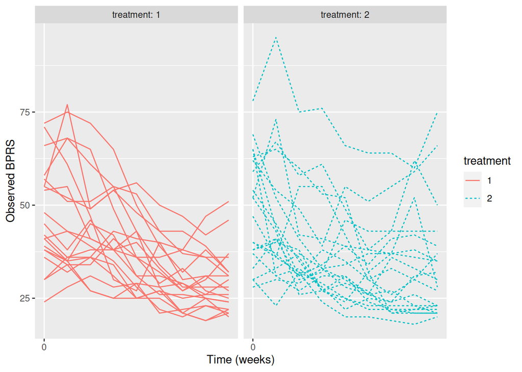

```r
# draw the plot of BPRSL with the observed BPRS values
ggplot(BPRSL, aes(x = week, y = bprs, group = ID, col=treatment)) +
  geom_line(aes(linetype = treatment)) +
  scale_x_continuous(name = "Time (weeks)", breaks = seq(0, 4, 8)) +
  scale_y_continuous(name = "Observed BPRS") +
  theme(legend.position = "right") +
  facet_grid(. ~ treatment, labeller=label_both)
```

```r
# Create a vector of the fitted values
Fitted <- fitted(BPRSL_ref)
Fitted1 <- fitted(BPRSL_ref1)
Fitted2 <- fitted(BPRSL_ref2)

# Create a new column fitted to BPRSL
BPRSL <- BPRSL %>% mutate(bprs_fitted_values_BPRSL_ref = Fitted, bprs_fitted_values_BPRSL_ref1 = Fitted1, bprs_fitted_values_BPRSL_ref2 = Fitted2)
head(BPRSL)
```

```
##   treatment subject weeks bprs week   ID bprs_fitted_values_BPRSL_ref
## 1         1       1 week0   42    0 1_t1                     50.39349
## 2         1       2 week0   58    0 2_t1                     53.42798
## 3         1       3 week0   54    0 3_t1                     46.52190
## 4         1       4 week0   55    0 4_t1                     61.06652
## 5         1       5 week0   72    0 5_t1                     60.96188
## 6         1       6 week0   48    0 6_t1                     44.74306
##   bprs_fitted_values_BPRSL_ref1 bprs_fitted_values_BPRSL_ref2
## 1                      39.66964                      40.11147
## 2                      63.89902                      64.08993
## 3                      52.23190                      52.47526
## 4                      62.50789                      62.81131
## 5                      74.47847                      74.63778
## 6                      46.17363                      46.46693
```

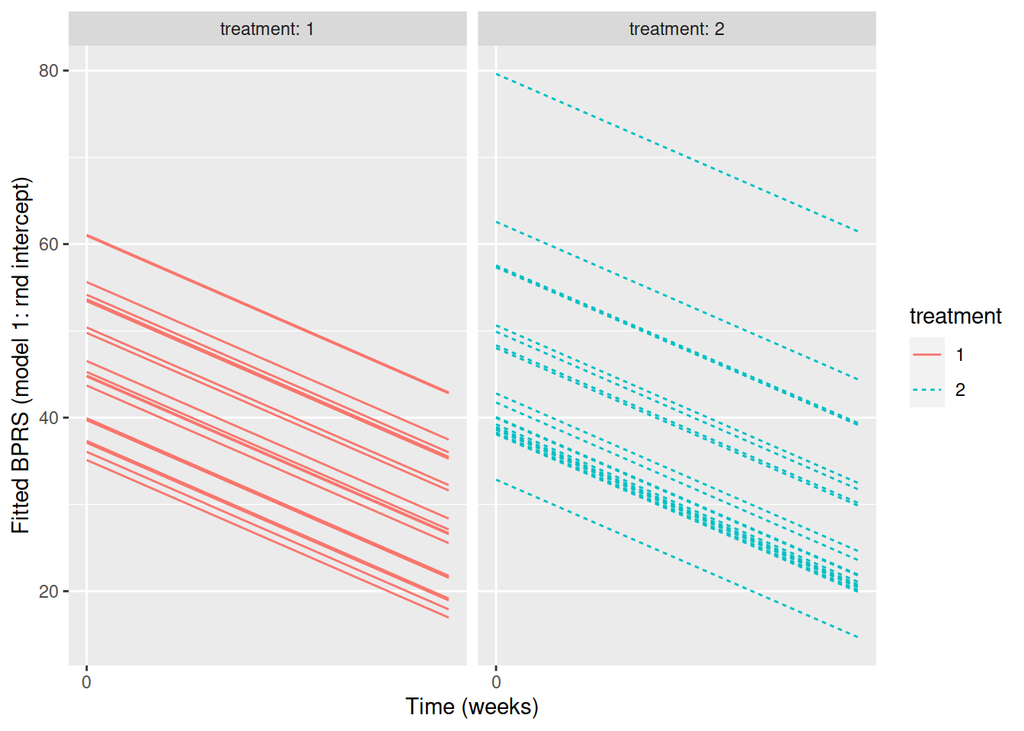

```r
# draw the plot of BPRSL with the Fitted values of bprs model 1
ggplot(BPRSL, aes(x = week, y = bprs_fitted_values_BPRSL_ref, group = ID, col=treatment)) +
  geom_line(aes(linetype = treatment)) +
  scale_x_continuous(name = "Time (weeks)", breaks = seq(0, 4, 8)) +
  scale_y_continuous(name = "Fitted BPRS (model 1: rnd intercept)") +
  theme(legend.position = "right") +
  facet_grid(. ~ treatment, labeller=label_both)
```